# BILGER-HANS-ADA-HOMEWORK-02

#### 2.f. Now draw 99 more random samples of 30 zombies out and calculate the mean for each of the these samples. Together with the first sample you drew out, you now have a set of 100 means for each variable (each based on 30 observations), which constitutes a sampling distribution for each variable. What are the means and standard deviations of the sampling distribution for each variable? How do the standard deviations compare to the standard errors estimated in [2.e.]? What do these sampling distributions look like? Are they normally distributed? What about for those variables that you concluded were not originally drawn from a normal distribution?

```r
## 99 more random samples
k <- 99
s <- NULL
for (i in 1:k) {
    s[[i]] <- sample_n(d, 30, replace=FALSE)
}
NewSample <- c(s, list(Zsample))
```

```r
#mean/sd of sampling distribution

#height
m_height <- NULL
for (i in 1:100) {
    m_height[i] <- mean(NewSample[[i]]$height)
}
mean(m_height)
```

```
## [1] 67.75672
```

```r
sd(m_height)
```

```
## [1] 0.777521
```

```r
#weight
m_weight <- NULL
for (i in 1:100) {
    m_weight[i] <- mean(NewSample[[i]]$weight)
}
mean(m_weight)
```

```
## [1] 144.429
```

```r
sd(m_weight)
```

```
## [1] 3.144868
```

```r
#age
m_age <- NULL
for (i in 1:100) {
    m_age[i] <- mean(NewSample[[i]]$age)
}
mean(m_age)
```

```
## [1] 20.09464
```

```r
sd(m_age)
```

```
## [1] 0.4856118
```

```r
#killed
m_killed <- NULL
for (i in 1:100) {
    m_killed[i] <- mean(NewSample[[i]]$zombies_killed)
}
mean(m_killed)
```

```
## [1] 2.929667
```

```r
sd(m_killed)
```

```
## [1] 0.3219224
```

```r
#ed
m_ed <- NULL
for (i in 1:100) {
    m_ed[i] <- mean(NewSample[[i]]$years_of_education)
}
mean(m_ed)
```

```
## [1] 3.017333
```

```r
sd(m_ed)
```

```
## [1] 0.2818282
```

```r
#sd and se comparison

sd(m_height)
```

```
## [1] 0.777521
```

```r
seZsample_height
```

```
## [1] 0.8913487
```

```r
sd(m_weight)
```

```
## [1] 3.144868
```

```r
seZsample_weight
```

```
## [1] 4.22497
```

```r
sd(m_age)
```

```
## [1] 0.4856118
```

```r
seZsample_age
```

```
## [1] 0.5642909
```

```r
sd(m_killed)
```

```
## [1] 0.3219224
```

```r
seZsample_killed
```

```
## [1] 0.3622514
```

```r
sd(m_ed)
```

```
## [1] 0.2818282
```

```r
seZsample_ed
```

```
## [1] 0.2368374
```

```r
#The standard deviations are generally close to the standard errors estimated in 2e.
```

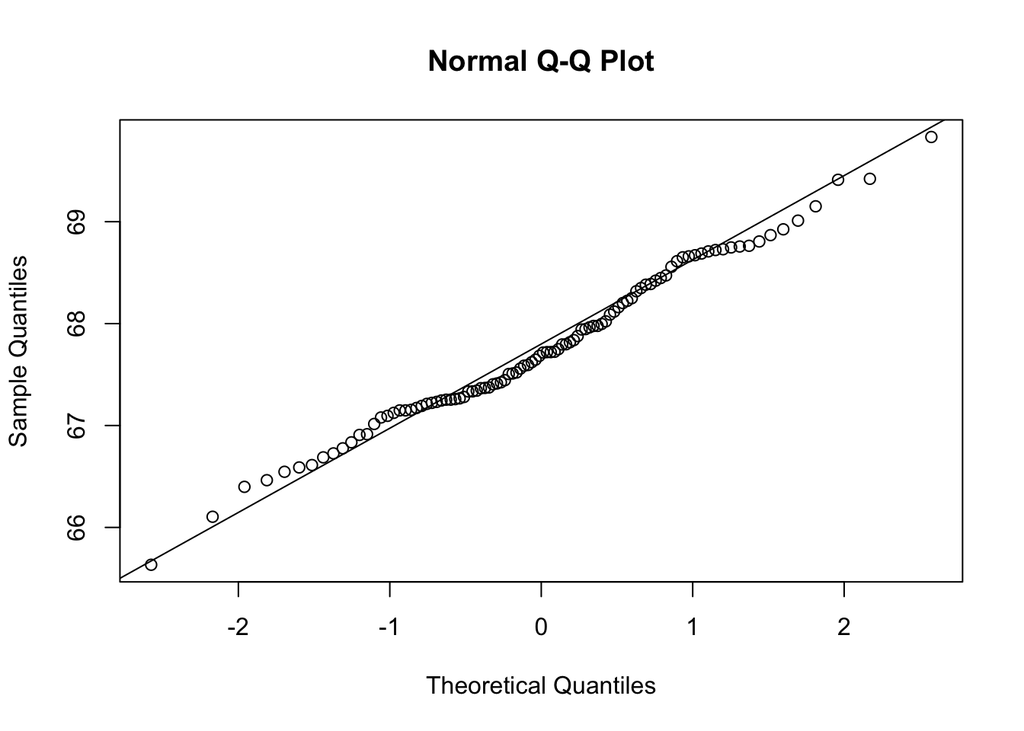

```r
# Sample distribution assessment — height

nqq_height <- qqnorm(m_height)
nqq_height <- qqline(m_height)
```

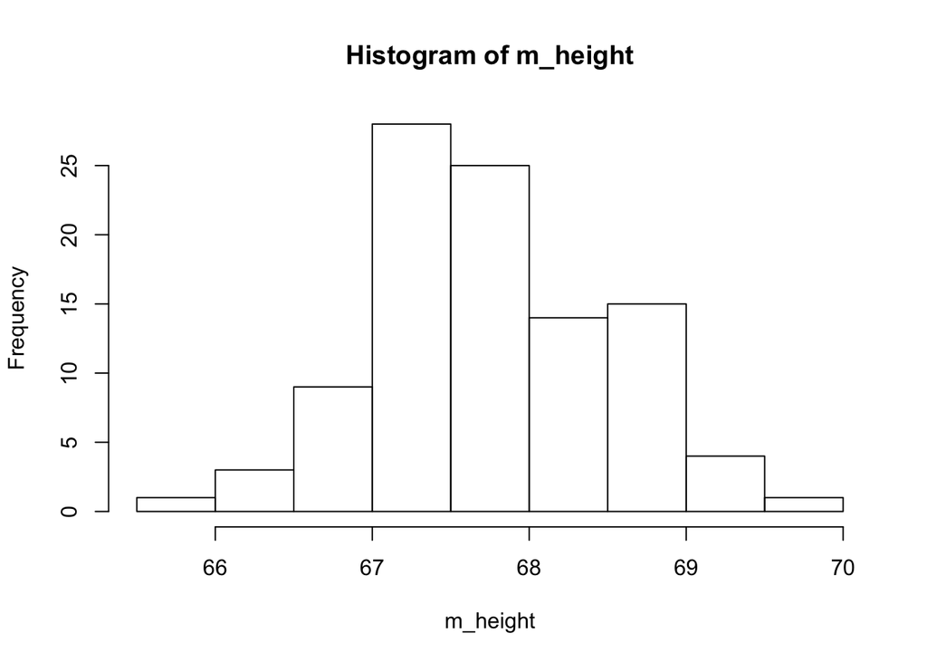

```r
nhist_height <- hist(m_height)
```

```r
#Sample distribution seems to deviate from a normal distribution at high and low values.
```

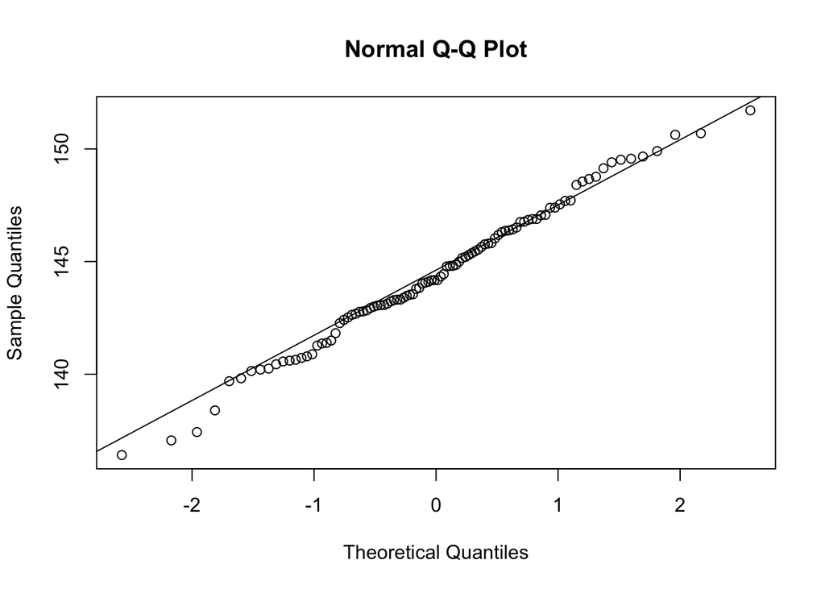

```r
# Sample distribution assessment — weight

nqq_weight <- qqnorm(m_weight)
nqq_weight <- qqline(m_weight)
```

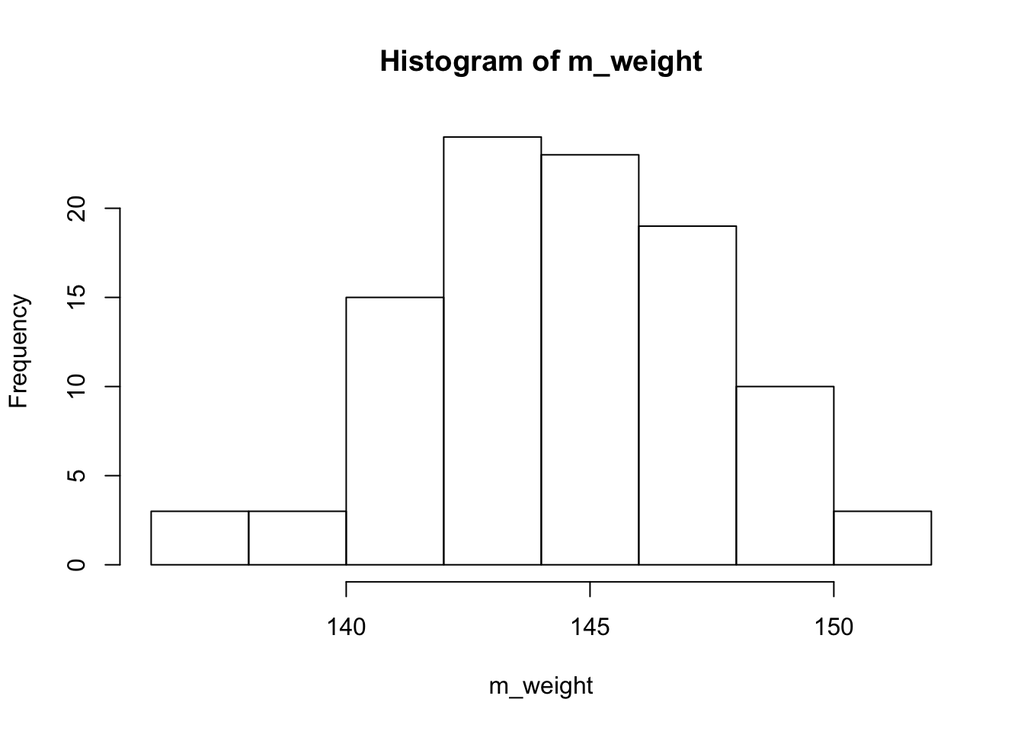

```r
nhist_weight <- hist(m_weight)
```

```r
# Sample distribution appears normal.
```

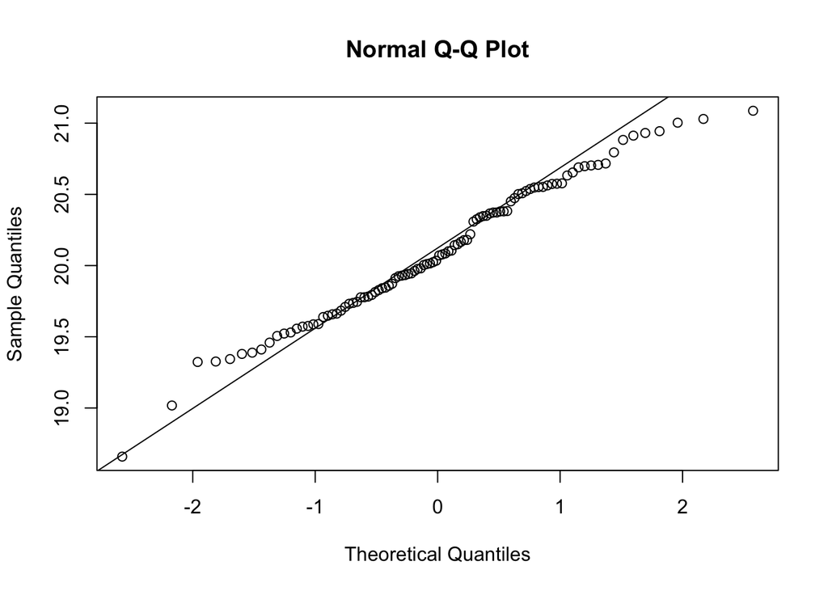

```r
# Sample distribution assessment — age

nqq_age <- qqnorm(m_age)
nqq_age <- qqline(m_age)
```

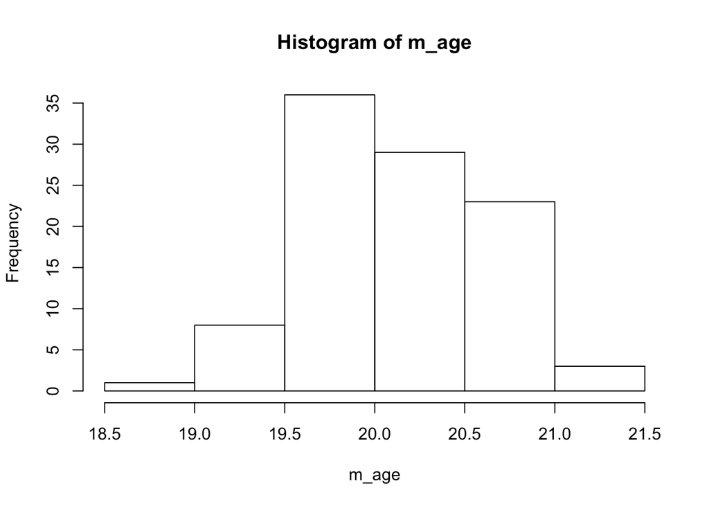

```r
nhist_age <- hist(m_age)
```

```r
# Sample distribution seems to deviate from a normal distribution at high and low values.
```

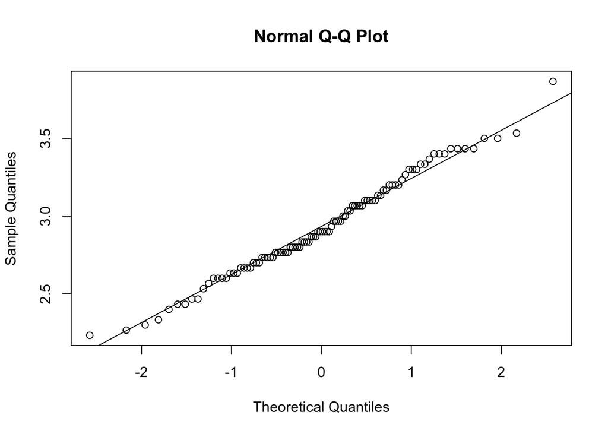

```r
# Sample distribution assessment — killed

nqq_killed <- qqnorm(m_killed)
nqq_killed <- qqline(m_killed)
```

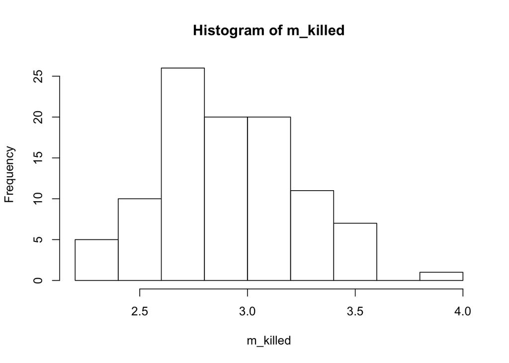

```r
nhist_killed <- hist(m_killed)
```

```r
# Sample distribution seems to deviate from a normal distribution at high and low values. This is from a variable that orignially seemed to be drawn from a Poisson distribution.
```

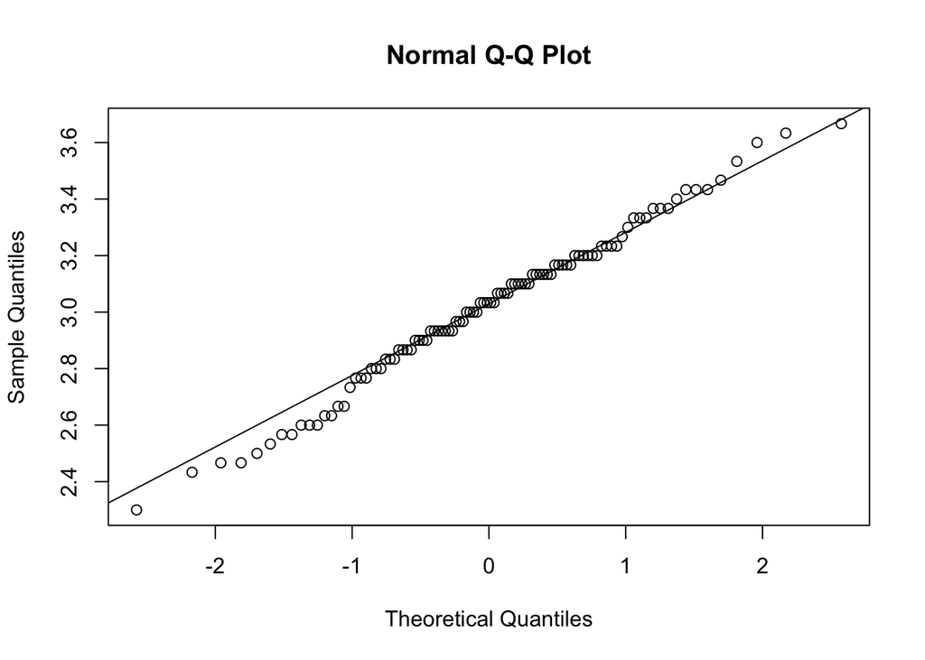

```r
# Sample distribution assessment — ed

nqq_ed <- qqnorm(m_ed)
nqq_ed <- qqline(m_ed)
```

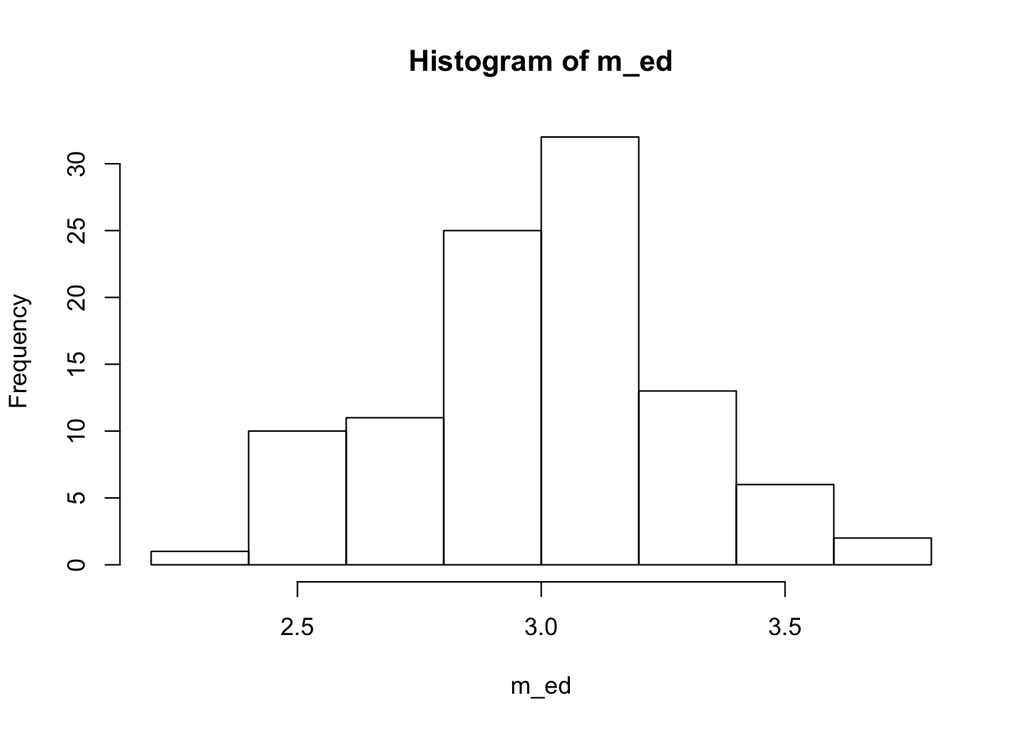

```r
nhist_ed <- hist(m_ed)
```

```r
# Sample distribution appears normal. This is from a variable that orignially seemed to be drawn from a Poisson distribution.
```